# Part II - Bike Data Analysis

## by Hastings Sibanda

## Investigation Overview

The Age and Gender profiles of clients was investigated. Generally, the majority of trips were taken by people in their 20s and 30s. Although there were notable riders in their 50s, and 60s. Outliers were also noted with the oldest recorded being 141 years old, which is very odd. Males dominated in trips, making up over 3 times more trips taken than Females. I also investigated time series data to show that most trips were taken during weekdays than on weekends.

## Dataset Overview

The dataset contained more than 170,000 rows of trip information for trips taken in February 2019 in the San Francisco Bay Area. Columns included member_age, trip_duration and trip_start_time.

## Gender Profile

The bulk of the trips were taken by Males who embarked on about 3 times more trips than Females, with the Other gender type having taken the least number of trips.

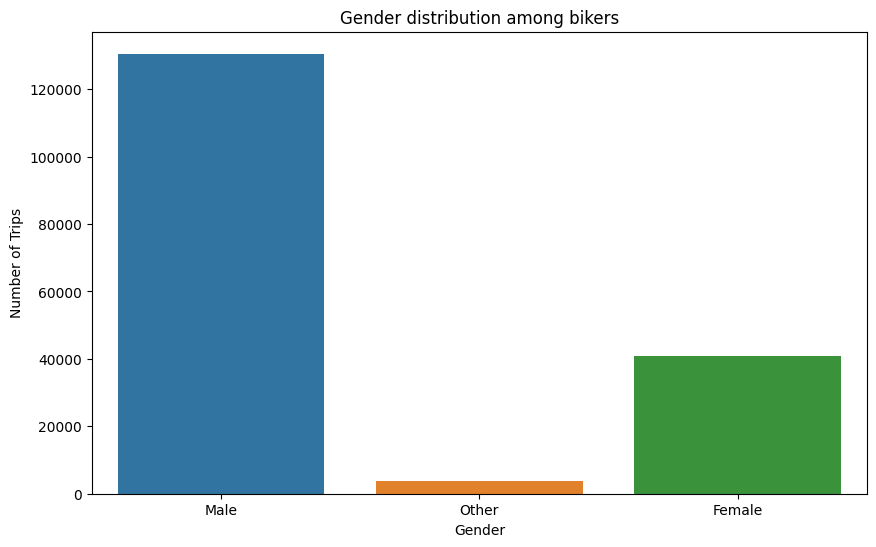

## Age Profile

Most of the riders were in their 20s and 30s. This makes sense because it is the age at which the normal human being is most physically active. However, some notable riders in their 50s and 60s. Whilst there a few odd outliers, the oldest being aged 141 years old.

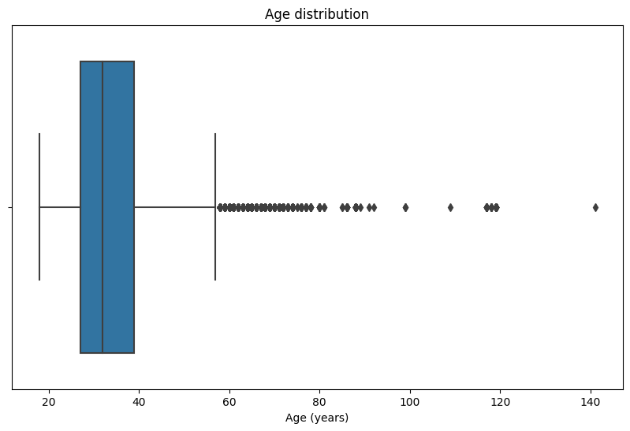

## Time Analysis

Riders prefer taking their bike trips during the week, than on weekends. The most trips notably being taken on Thursdays, followed by Tuesdays. The least number of trips were taken on Saturdays.

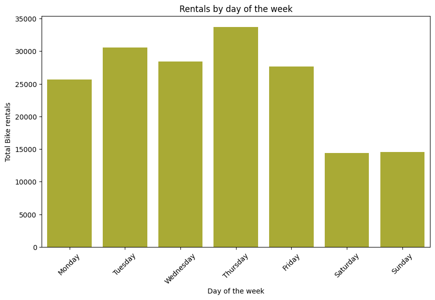